# Hummingbird Migration by Latitude

### Import python packages needed for this project

```python
#import pandas and numpy libraries
import pandas as pd
import numpy as np
import sys #sys needed only for python version
import seaborn as sns

#display versions of python and packages
print('\npython version ' + sys.version)
print('pandas version ' + pd.__version__)
print('numpy version ' + np.__version__)
print('seaborn version ' + sns.__version__)
```

```
python version 3.5.1 |Anaconda 2.4.1 (64-bit)| (default, Jan 29 2016, 15:01:46) [MSC v.1900 64 bit (AMD64)]
pandas version 0.17.1
numpy version 1.10.4
seaborn version 0.7.0
```

### Import Cornell Ornithology eBird Hummingbird sighting data

*Ruby-throated hummingbird sightings from January 2013 to August 2015, capturing 3 years of south-to-north migration, and at least 2 years north-to-south* http://ebird.org/content/ebird/

```python
# read in text file, which is tab delimited, and set global unique indentifier as the index column
df = pd.read_csv('ebird_rubythroated_Jan2013_Aug2015.txt', sep='\t', index_col='GLOBAL UNIQUE IDENTIFIER',
                 error_bad_lines=False, warn_bad_lines=False, low_memory=False)
# received error on one row of data...
# pandas.parser.CParserError: Error tokenizing data. C error: Expected 44 fields in line 36575, saw 45
# set error_bad_lines to false so it would just skip that line and keep going
# received dtype error on some columns having mixed-type data. added low_memory=False option to resolve.

# set pandas to output all of the columns in output (was truncating)
pd.options.display.max_columns = 50

# display the first 10 rows to view example data (this time all columns)
print(df.head(n=2))
```

```
                                                TAXONOMIC ORDER CATEGORY  \
GLOBAL UNIQUE IDENTIFIER
URN:CornellLabOfOrnithology:EBIRD:OBS289095158             8896  species
URN:CornellLabOfOrnithology:EBIRD:OBS290371528             8896  species

                                                              COMMON NAME  \
GLOBAL UNIQUE IDENTIFIER
URN:CornellLabOfOrnithology:EBIRD:OBS289095158  Ruby-throated Hummingbird
URN:CornellLabOfOrnithology:EBIRD:OBS290371528  Ruby-throated Hummingbird

                                                     SCIENTIFIC NAME  \
GLOBAL UNIQUE IDENTIFIER
URN:CornellLabOfOrnithology:EBIRD:OBS289095158  Archilochus colubris
URN:CornellLabOfOrnithology:EBIRD:OBS290371528  Archilochus colubris

                                                SUBSPECIES COMMON NAME  \
GLOBAL UNIQUE IDENTIFIER
URN:CornellLabOfOrnithology:EBIRD:OBS289095158                     NaN
URN:CornellLabOfOrnithology:EBIRD:OBS290371528                     NaN

                                                SUBSPECIES SCIENTIFIC NAME  \
GLOBAL UNIQUE IDENTIFIER
URN:CornellLabOfOrnithology:EBIRD:OBS289095158                         NaN
URN:CornellLabOfOrnithology:EBIRD:OBS290371528                         NaN

                                               OBSERVATION COUNT  \
GLOBAL UNIQUE IDENTIFIER
URN:CornellLabOfOrnithology:EBIRD:OBS289095158                 1
URN:CornellLabOfOrnithology:EBIRD:OBS290371528                 1

                                               BREEDING BIRD ATLAS CODE  \
GLOBAL UNIQUE IDENTIFIER
URN:CornellLabOfOrnithology:EBIRD:OBS289095158                      NaN
URN:CornellLabOfOrnithology:EBIRD:OBS290371528                      NaN

                                                                  AGE/SEX  \
GLOBAL UNIQUE IDENTIFIER
URN:CornellLabOfOrnithology:EBIRD:OBS289095158                        NaN
URN:CornellLabOfOrnithology:EBIRD:OBS290371528  Unknown Sex, Immature (1)

```

[output cut: 89 more lines]

```

                                                ALL SPECIES REPORTED  \
GLOBAL UNIQUE IDENTIFIER
URN:CornellLabOfOrnithology:EBIRD:OBS289095158                     1
URN:CornellLabOfOrnithology:EBIRD:OBS290371528                     1

                                               GROUP IDENTIFIER  APPROVED  \
GLOBAL UNIQUE IDENTIFIER
URN:CornellLabOfOrnithology:EBIRD:OBS289095158              NaN         1
URN:CornellLabOfOrnithology:EBIRD:OBS290371528              NaN         1

                                                REVIEWED  REASON  Unnamed: 43
GLOBAL UNIQUE IDENTIFIER
URN:CornellLabOfOrnithology:EBIRD:OBS289095158         1     NaN          NaN
URN:CornellLabOfOrnithology:EBIRD:OBS290371528         1     NaN          NaN
```

```python
# easier to read example of values in 1 row. picked 1000 because it's not far south like head rows are
print(df.iloc[2000,:])
```

```
TAXONOMIC ORDER                                               8896
CATEGORY                                                   species
COMMON NAME                              Ruby-throated Hummingbird
SCIENTIFIC NAME                               Archilochus colubris
SUBSPECIES COMMON NAME                                         NaN
SUBSPECIES SCIENTIFIC NAME                                     NaN
OBSERVATION COUNT                                                1
BREEDING BIRD ATLAS CODE                                       NaN
AGE/SEX                                                        NaN
COUNTRY                                                     Canada
COUNTRY_CODE                                                    CA
STATE_PROVINCE                                       New Brunswick
SUBNATIONAL1_CODE                                            CA-NB
COUNTY                                                   Charlotte
SUBNATIONAL2_CODE                                         CA-NB-CH
IBA CODE                                                 CA-NB_011
BCR CODE                                                        14
ATLAS BLOCK                                                    NaN
LOCALITY                                            Castalia Marsh
LOCALITY ID                                                L164896
LOCALITY TYPE                                                    H
LATITUDE                                                   44.7242
LONGITUDE                                                 -66.7543
OBSERVATION DATE                                        2013-07-18
TIME OBSERVATIONS STARTED                                 19:15:00
TRIP COMMENTS                 Viewed from cabin at Castalia Marsh.
SPECIES COMMENTS                                               NaN
OBSERVER ID                                             obsr298478
FIRST NAME                                                    Kris
LAST NAME                                                      Ito
SAMPLING EVENT IDENTIFIER                                S14810638
PROTOCOL TYPE                             eBird - Stationary Count
PROJECT CODE                                             EBIRD_CAN
DURATION MINUTES                                                45
EFFORT DISTANCE KM                                             NaN
EFFORT AREA HA                                                 NaN
NUMBER OBSERVERS                                                 1
ALL SPECIES REPORTED                                             1
GROUP IDENTIFIER                                               NaN
APPROVED                                                         1
REVIEWED                                                         0
REASON                                                         NaN
Unnamed: 43                                                    NaN
Name: URN:CornellLabOfOrnithology:EBIRD:OBS206154144, dtype: object
```

```python
# narrow dataset down to just columns we need
df_loc_date = df.loc[:,('COUNTRY','STATE_PROVINCE','LOCALITY','COUNTY','LATITUDE','LONGITUDE','OBSERVATION DATE')]

# put the month, year, and date into their own columns
df_loc_date['OBS MONTH'] = df_loc_date['OBSERVATION DATE'].str[5:7].astype(int)
df_loc_date['OBS DAY'] = df_loc_date['OBSERVATION DATE'].str[8:10].astype(int)
df_loc_date['OBS YEAR'] = df_loc_date['OBSERVATION DATE'].str[0:4].astype(int)
# pretend they're all in the same year so we can get earliest month and day and treat like a date
df_loc_date['OBS MONTHDAY'] = '2014-' + df_loc_date['OBSERVATION DATE'].str[5:10].astype(str)
df_loc_date['OBS MONTHDAY'] = pd.to_datetime(df_loc_date['OBS MONTHDAY'])

# add columns for rounded latitude and longitude to make it less granular
df_loc_date['SHORT LAT'] = df_loc_date['LATITUDE'].round(0)
df_loc_date['SHORT LONG'] = df_loc_date['LONGITUDE'].round(0)

print(df_loc_date.iloc[2000,:])
```

```
COUNTRY                          Canada
STATE_PROVINCE            New Brunswick
LOCALITY                 Castalia Marsh
COUNTY                        Charlotte
LATITUDE                        44.7242
LONGITUDE                      -66.7543
OBSERVATION DATE             2013-07-18
OBS MONTH                             7
OBS DAY                              18
OBS YEAR                           2013
OBS MONTHDAY        2014-07-18 00:00:00
SHORT LAT                            45
SHORT LONG                          -67
Name: URN:CornellLabOfOrnithology:EBIRD:OBS206154144, dtype: object
```

### We made the latitude and longitude data less granular so we have more points per location to calculate minimum date seen. Visualize to show granularity.

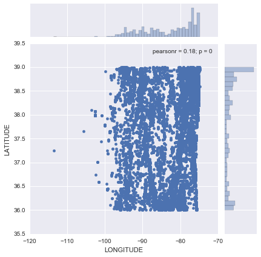

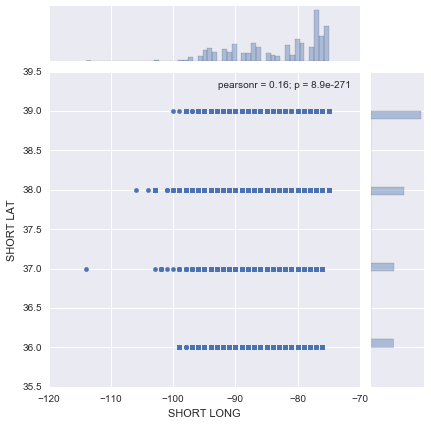

```python
#show the plot here instead of in pop-up
%matplotlib inline
# seaborn joint plot with latitude and longitude
sns.jointplot("LONGITUDE", "LATITUDE", data=df_loc_date.where((df_loc_date['LATITUDE'] > 36) & (df_loc_date['LATITUDE'] < 39 )))
sns.plt.show()
# seaborn joint plot with less-granular latitude and longitude
sns.jointplot("SHORT LONG", "SHORT LAT", data=df_loc_date.where((df_loc_date['LATITUDE'] > 36) & (df_loc_date['LATITUDE'] < 39 )))
sns.plt.show()
```

### Create a pivot table that will show the minimum month/day a hummingbird was seen in each area (in any of the 3 years)

```python
# get the earliest sighting in any year by short long and short lat group
df_first_seen = df_loc_date.loc[:,('SHORT LAT','SHORT LONG','OBS MONTHDAY')].groupby(['SHORT LAT','SHORT LONG']).min()

#here's how the pivot table looks
print(df_first_seen.head(n=20))
```

```
                     OBS MONTHDAY
SHORT LAT SHORT LONG
8         -84          2014-02-05
          -83          2014-01-19
          -80          2014-02-04
9         -84          2014-01-12
          -83          2014-01-09
          -82          2014-02-25
10        -86          2014-01-02
          -85          2014-01-01
          -84          2014-01-01
11        -86          2014-01-01
          -85          2014-01-08
          -84          2014-01-20
12        -87          2014-03-03
          -86          2014-01-01
          -85          2014-02-16
13        -89          2014-01-06
          -88          2014-01-15
          -87          2014-01-05
          -86          2014-02-09
14        -91          2014-01-17
```

```python
# and here's how to access a value by index
print(df_first_seen.dtypes)
print(df_first_seen.ix[9,-84])
```

```
OBS MONTHDAY    datetime64[ns]
dtype: object
OBS MONTHDAY   2014-01-12
Name: (9.0, -84.0), dtype: datetime64[ns]
```

```python
# however, I don't want those values to be indexes, I want it to act like a normal dataframe
df_first_seen = df_first_seen.reset_index()
print(df_first_seen.dtypes)
lat96 = df_first_seen[df_first_seen['SHORT LAT'] == 9]
print(lat96[lat96['SHORT LONG'] == -84])
print(df_first_seen.shape)
```

[output not shown]

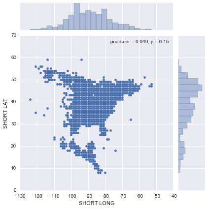

```python
# seaborn joint plot with less-granular latitude and longitude
sns.jointplot("SHORT LONG", "SHORT LAT", data=df_first_seen) #where((df_first_seen['SHORT LAT'] >= 36) & (df_first_seen['SHORT'] <= 39 )))
sns.plt.show()
```

### Let's see how the week-number of first observations are distributed

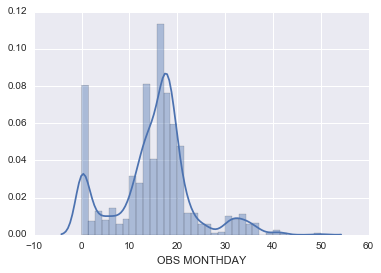

```python
sns.distplot(df_first_seen['OBS MONTHDAY'].apply(lambda x: int((x.timetuple().tm_yday/7))))
sns.plt.show()
```

### need color scheme to show migration change by weeks and show scatterplot as if map

*but most weeks are between 10 and 20.... so after setting colors 1-52 for weeks, I ended up "skipping" through colors up to week 26, then making weeks 26+ all the max color*

```python
#import packages needed for bokeh plots on date-related data
from bokeh.plotting import *
from bokeh.palettes import Spectral6
import datetime

#set plots to show up inline
output_notebook()

#create labels for "map" plot
p = figure(title = "Ruby-Throated Hummingbird Migration Map (colors tied to week of 1st observation)")
p.xaxis.axis_label = 'Longitude'
p.yaxis.axis_label = 'Latitude'
p.title_text_font_size = '8'

#determine the range or values
plotdata = df_first_seen #.where((df_first_seen['SHORT LAT'] >= 36) & (df_first_seen['SHORT LAT'] <= 39 ))
high = plotdata['OBS MONTHDAY'].max().timetuple().tm_yday/7 #highest year day in resulting set
low = plotdata['OBS MONTHDAY'].min().timetuple().tm_yday/7 #lowest year day in resulting set
#print(int(low),int(high)) #weeks 1 to 52
matrix = [ ([i*85] * 13) for i in range(4) ]
plotdata['WOY'] = plotdata['OBS MONTHDAY'].apply(lambda x: int((x.timetuple().tm_yday/7/((high-low)/52))))
r = [x for row in reversed(matrix) for x in row]# [x*4.4 for x in range(0,53)]
g = [x*4.4 for x in range(0,53)]
b = [x for row in matrix for x in row] #need one more value
b.append(255)
r.append(0)
#convert to hex values
colors = [
    "#%02x%02x%02x" % (int(r), 50, int(b)) for r,g,b in zip(r,g,b)
 ]
#print(plotdata['WOY'].max())
color_dict = {}
#assign a hex color to each value for first sighting 0-52 weeks
color_dict = dict(zip(range(0,53),colors))
#print(color_dict)
#assign colors to values in table to be plotted
colors = [color_dict[x*2] if x < 26 else color_dict[52] for x in plotdata['WOY']] #added *2 to skip though these colors faster, until > 26, then stay at max
#print(colors)

# NOTE FOR LATER: show example location name on select?

#create and display the "map"
p.circle(plotdata['SHORT LONG'], plotdata['SHORT LAT'],
        fill_color=colors, line_color = None, fill_alpha = 0.8 )
show(p)
```

BokehJS successfully loaded.

### Now going to create some interactivity.

People don't usually know the latitude of their location, so I'm creating another grouped dataframe, this time by city and state, to find min date observed (some small-population areas may not have many data points)

```python
# get the earliest sighting in any year by short long and short lat group
df_first_city_state = df_loc_date.loc[:,('SHORT LAT','SHORT LONG','COUNTRY','STATE_PROVINCE','COUNTY','LOCALITY','OBS MONTHDAY')].groupby(['COUNTRY','STATE_PROVINCE','COUNTY'])
df_first_city_state = df_first_city_state.agg({'OBS MONTHDAY' : np.min, 'SHORT LAT': np.mean, 'SHORT LONG': np.mean})
#pd.set_option('display.max_rows', len(df_first_city_state))
count_orig=df_loc_date.where((df_loc_date['COUNTRY'] == 'United States') & (df_loc_date['STATE_PROVINCE'] == 'Virginia') & (df_loc_date['COUNTY'] == 'Harrisonburg')).count()
print('There are',count_orig[1], 'observations in Harrisonburg, VA')
df_city_state_co_summary = df_first_city_state.ix['United States','Virginia','Harrisonburg']
print('AVG LATITUDE:',df_city_state_co_summary[0])
print('AVG LONGITUDE:',df_city_state_co_summary[2])
obs_mon = df_city_state_co_summary[1].timetuple().tm_mon
obs_day = df_city_state_co_summary[1].timetuple().tm_mday
print('EARLIEST SIGHTING:',str(obs_mon)+'/'+str(obs_day))
#pd.reset_option('display.max_rows')
```

```
There are 33 observations in Harrisonburg, VA
AVG LATITUDE: 38.0
AVG LONGITUDE: -79.0
EARLIEST SIGHTING: 5/2
```

```python
#show map with distribution by this date
max_date = pd.to_datetime('2014-' + str(obs_mon).zfill(2) + '-' + str(obs_day).zfill(2))
plotdata_date = plotdata[plotdata['OBS MONTHDAY'] <= max_date]
#print(plotdata_date)

#create new map plot
#create labels for "map" plot
p2 = figure(title = "Ruby-Throated Hummingbird Migration Through " + str(obs_mon)+'/'+str(obs_day))
p2.xaxis.axis_label = 'Longitude'
p2.yaxis.axis_label = 'Latitude'
p2.title_text_font_size = '8'
colors = [color_dict[x*2] if x < 26 else color_dict[52] for x in plotdata_date['WOY']] #added *2 to skip though these colors faster, until > 26, then stay at max
#map points
p2.circle(plotdata_date['SHORT LONG'], plotdata_date['SHORT LAT'],fill_color=colors, line_color = None, fill_alpha = 0.8 )
#get the actual color of the dot
plotdata_loc = plotdata_date.loc[(plotdata_date['SHORT LONG'] == df_city_state_co_summary[2]) & (plotdata_date['SHORT LAT'] == df_city_state_co_summary[0] )]
color2 = [color_dict[x*2] if x < 26 else color_dict[52] for x in plotdata_loc['WOY']]
#larger point to indicate county
p2.circle_x(df_city_state_co_summary[2], df_city_state_co_summary[0],fill_color=color2, line_color = "black", fill_alpha = 0.8, size=15 )
show(p2)
```

### show range with dynamic month and day entry

```python
#show map with distribution by this date
#mon_day = '0501'
from ipywidgets import *
from bokeh.models import Range1d
myslider = IntSlider(min=1,max=365,description="Day of Year")
myslider.value = 60
#display(myslider)


def mapMigrationByDate(md):
    max_date = datetime.datetime(2014, 1, 1) + datetime.timedelta(md - 1)
    plotdata_date = plotdata[plotdata['OBS MONTHDAY'] <= max_date]
    #print(plotdata_date)
    obs_mon2 = max_date.timetuple().tm_mon
    obs_day2 = max_date.timetuple().tm_mday

    #create new map plot
    #create labels for "map" plot
    p3 = figure(title = "Ruby-Throated Hummingbird Migration Through " + str(obs_mon2)+'/'+str(obs_day2))
    p3.xaxis.axis_label = 'Longitude'
    p3.yaxis.axis_label = 'Latitude'
    # fixed axes on this one for visual effect
    p3.xaxis.bounds = [-130,-50]
    p3.yaxis.bounds = [5,60]
    p3.x_range = Range1d(-130,-50)
    p3.y_range = Range1d(5,60)
    p3.title_text_font_size = '8'
    colors = [color_dict[x*2] if x < 26 else color_dict[52] for x in plotdata_date['WOY']] #added *2 to skip though these colors faster, until > 26, then stay at max
    #map points
    p3.circle(plotdata_date['SHORT LONG'], plotdata_date['SHORT LAT'],fill_color=colors, line_color = None, fill_alpha = 0.8 )
    show(p3)

interact(mapMigrationByDate,md=myslider)
mapMigrationByDate(60)
```

### let's try to put this on a Google Map

```python
# http://bokeh.pydata.org/en/latest/docs/user_guide/geo.html
from bokeh.models import (
  GMapPlot, GMapOptions, ColumnDataSource, Circle, DataRange1d, PanTool, WheelZoomTool, BoxSelectTool, BoxZoomTool
)

map_options = GMapOptions(lat=35, lng=-90, map_type="roadmap", zoom=3)

plot = GMapPlot(
    x_range=DataRange1d(), y_range=DataRange1d(), map_options=map_options, title="Google Map"
)

source = ColumnDataSource(
    data=dict(
        lat= plotdata['SHORT LAT'],
        lon= plotdata['SHORT LONG']
    )
)

circle = Circle(x="lon", y="lat", size=8, fill_color="blue", fill_alpha=0.8, line_color=None)
plot.add_glyph(source, circle)

#NOTE - zoom not allowed?
plot.add_tools(PanTool(), WheelZoomTool(), BoxSelectTool(), BoxZoomTool())
#output_file("gmap_plot.html")
show(plot)
```